# Análisis GeoEspacial: Maternidad Adolescente vs Educación

Trabajo N° 1 - Geomarketing

Felipe Larrabe Cabrera

2025-10-18

# 1 - Introducción

La maternidad adolescente representa un desafío crítico para las políticas públicas en Chile, especialmente en lo que respecta a la salud, la educación y la equidad social. Esta problemática, más allá de ser un asunto de salud reproductiva, tiene profundas implicancias en la trayectoria de vida de las jóvenes afectadas, limitando sus oportunidades educativas, laborales y de movilidad social. Como señala Huerta Wong (2012, p. 67), “La escolaridad es considerada una herramienta poderosa para superar barreras estructurales, principalmente en poblaciones vulnerables”. Sin embargo, la maternidad temprana frecuentemente interrumpe este camino, perpetuando ciclos de pobreza y exclusión.

Diversos estudios evidencian una correlación negativa entre la maternidad temprana y la continuidad educacional, donde las adolescentes que son madres presentan una mayor propensión a abandonar el sistema escolar. Esta situación no solo afecta el capital humano individual, sino que tiene implicancias en el desarrollo económico nacional y en la capacidad de las jóvenes para ascender en la escala socioeconómica.

El embarazo adolescente se relaciona bidireccionalmente con la pobreza multidimensional: las condiciones socioeconómicas adversas aumentan su ocurrencia, y a su vez, la maternidad temprana profundiza las desigualdades preexistentes. En este contexto, resulta fundamental incorporar una perspectiva territorial que permita identificar patrones espaciales y zonas críticas donde coinciden altas tasas de maternidad adolescente con baja asistencia educacional.

Este trabajo busca analizar espacialmente la relación entre maternidad adolescente y la permanencia en el sistema educativo, en las zonas urbanas del Gran Santiago (Provincia de Santiago y comunas de Puente Alto y San Bernardo), con el propósito de generar evidencia empírica que contribuya a la toma de decisiones y al diseño de políticas públicas efectivas para reducir la ocurrencia de estos casos en las zonas más vulnerables. Para ello, se utilizaron datos del CENSO 2017 de mujeres adolescentes (15-19 años), empleando herramientas como PostgreSQL para el manejo de datos y Rstudio para el análisis espacial, junto con la librería “biscale” para la generación de mapas bivariados que visualizan la relación entre madres adolescentes y su permanencia en el sistema educativo.

## 1.1 - Objetivo General

Explorar y analizar la distribución espacial de la maternidad adolescente y su relación con la asistencia educacional en mujeres adolescentes (15 a 19 años) en zonas urbanas seleccionadas de la Región Metropolitana de Santiago, utilizando datos del CENSO 2017 y representaciones bivariadas.

## 1.2 - Objetivos Específicos

- Identificar las zonas censales urbanas con mayores tasas de maternidad adolescente en la zona Urbana del Gran Santiago.
- Analizar la distribución de la asistencia educacional entre adolescentes en las mismas zonas.
- Generar mapas bivariados que permitan visualizar la intersección entre ambas vulnerabilidades a nivel territorial.
- Detectar patrones espaciales críticos que evidencien mayor vulnerabilidad socioeducativa.

# 2 - Desarrollo

## 2.1 - Metodología

Se utilizaron los programas RStudio (versión RStudio 2025.09.1+401 (Windows)) y PostgreSQL (versión 13) para el análisis de datos y gestión de la base de datos del Censo 2017. El análisis se centró en la población de mujeres adolescentes (15-19 años) de las zonas urbanas de la provincia de Santiago y de las comunas de Puente Alto y San Bernardo, con el objetivo de examinar la relación entre la maternidad adolescente y la permanencia en el sistema educativo. Para ello, se calcularon indicadores de tasa de maternidad adolescente y tasa de asistencia a educación formal en este grupo poblacional.

### 2.1.1 - Librerías

Para poder analizar los datos en Rstudio fue necesario ocupar las siguientes librerías:

```r
library(DBI)
library(RPostgres)
library(sf)
library(ggplot2)
library(cowplot)
library(biscale)
library(dplyr)
```

Las librerías DBI y RPostgres permiten la conexión y consulta a bases de datos PostgreSQL; sf maneja datos espaciales y geometrías para mapas; ggplot2 genera visualizaciones y gráficos estáticos; cowplot combina y organiza múltiples gráficos en un mismo layout; biscale crea mapas bivariados que representan dos variables simultáneamente mediante escalas de color; y dplyr facilita la manipulación y transformación de datos mediante una sintaxis intuitiva y consistente.

### 2.1.2 - Conexión al Servidor de la Base de Datos SQL

La conexión al servidor SQL con los datos del censo de la Región Metropolitana de Chile, se estableció en utilizando a los siguientes parámetros:

```r
con <- dbConnect(
  Postgres(),
  dbname = "censo_rm",
  host = "localhost",
  port = 5432,
  user = "postgres",
  password = "1234"
)
```

### 2.1.2 - Indicadores (SQL)

Las variables a utilizar del censo 2017 fueron las siguientes:

| Variable | Descripción | Tipo de datos y rangos | Valores escogidos |
| --- | --- | --- | --- |
| p08 | Sexo | Integer [1-2] | p08 = 2 = Mujer |
| p09 | Edad | Integer [0-130] | 15 ≤ p09 ≤19 |
| p13 | Asiste Actualmente A Educación Formal | Integer [1-3] | p13 = 1 = Sí |
| p19 | Total Hijos/as Nacidos Vivos | Integer [0-23] | p19 ≥ 1 |

En donde la tasa de Maternidad Adolescente fue calculada como:

$$\text{Tasa de Maternidad} = \left( \frac{\text{Número de mujeres (15-19
años, con al menos 1 Hijo vivo}}{\text{Total de mujeres en el grupo
etario( 15-19 años}} \right) \times 100\$$

Utilizando los siguientes filtros en SQL:

$p.p08 = 2$ $AND$ $p.p09$ $BETWEEN$ $15$ $AND$ $19$ $AND$ $p.p19 >= 1$ , siendo esto el número de mujeres adolescentes con un hijo y $p.p08 = 2$ $AND$ $p.p09$ $BETWEEN$ $15$ $AND$ $19$ el total de mujeres adolescentes

Por otra parte, la tasa de Asistencia o prosecución de estudios, es calcula de la siguiente forma:

$$\text{Tasa de Asistencia Educacional} = \left( \frac{\text{Número de
mujeres (15-19 años), que asisten a educación formal}}{\text{Total de
mujeres en el grupo etario( 15-19 años}} \right) \times 100\$$

Siendo el número de mujeres que asiste a educación formal, obtenido a través de este código SQL: $p.p08 = 2$ $AND$ $p.p09$ $BETWEEN$ $15$ $AND$ $19$ $AND$ $p.p13 = 1$ .

Con las tablas generadas por estas tasas a nivel de unidad censal, se aplicó un filtro en donde se restringió el área de estudio a las zonas urbanas de la provincia de Santiago y las comunas de puente alto y san bernardo, para luego unir dichos datos tabulares con las geometrías a través de los geocodigos presentes en la base de datos.

```r
#=============================================================================
# 4) CARGAR GEOMETRÍA DE ZONAS CENSALES CON LOS MISMOS FILTROS
#=============================================================================
sql_geometria <- "
SELECT geocodigo::double precision AS geocodigo, geom
FROM dpa.zonas_censales_rm
WHERE urbano = 1 AND (nom_provin = 'SANTIAGO' OR nom_comuna IN ('PUENTE ALTO', 'SAN BERNARDO'));
"

sf_zonas <- st_read(con, query = sql_geometria)

#=============================================================================
# 5) COMBINAR DATOS TABULARES Y ESPACIALES
#=============================================================================
sf_mapa <- left_join(sf_zonas, df_indicadores, by = "geocodigo")
```

## 2.2 - Análisis Exploratorio de datos

Con el objetivo de comprender la distribución y relación entre las variables de estudio, se realizó un análisis exploratorio de los datos. Inicialmente, se examinó la dispersión de cada variable mediante histogramas para determinar la forma más adecuada de representar las diferencias en su distribución. Posteriormente, se analizó la correlación entre ambas variables a través de un diagrama de dispersión (scatterplot), donde cada punto fue clasificado en tres categorías (baja, media y alta) basadas en **cuartiles** (utilizando los percentiles 25% y 75% como puntos de corte), permitiendo visualizar patrones de asociación entre la maternidad adolescente y la asistencia educacional de manera más efectiva.

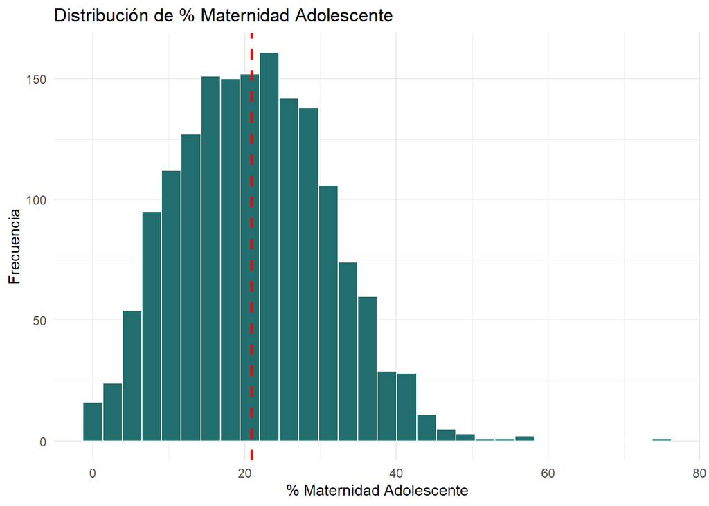

Es posible apreciar, a partir de la figura, que por lo general la maternidad adolescente posee valores bajos evidenciado en la concentración significativa de los datos entre el 10% y el 30%, con una mediana cercana al 22%. La distribución presenta una asimetría positiva, evidenciada por una mayor frecuencia de valores en torno al 20%, lo que indica que la mayoría de las observaciones se agrupan en ese rango. A partir del 30%, la frecuencia disminuye progresivamente, lo que sugiere que los valores más altos son menos comunes. Aquellos superiores al 60% podrían considerarse valores atípicos.

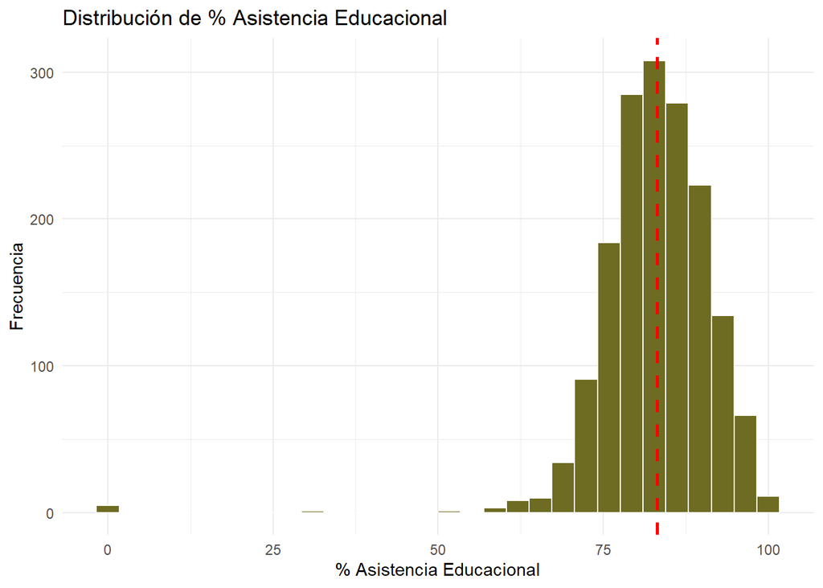

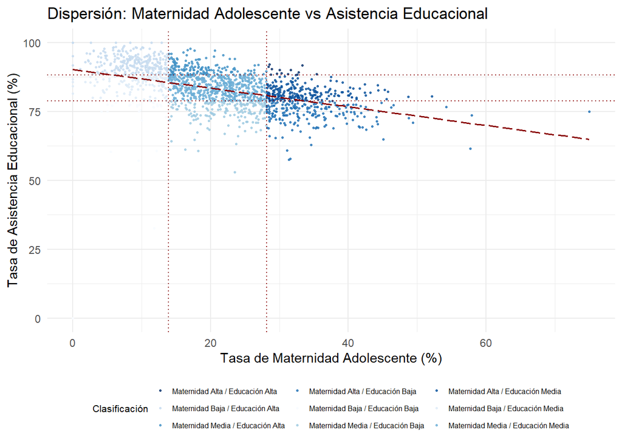

Debido a la marcada concentración de los datos observada en los histogramas, se optó por utilizar los percentiles 25% y 75% como puntos de corte para clasificar los valores en tres categorías (baja, media y alta), facilitando así la visualización de las diferencias territoriales en las relaciones entre las variables.

El gráfico de dispersión evidencia una clara correlación negativa entre la maternidad adolescente y la asistencia educacional, representada mediante una línea de tendencia roja ajustada por regresión lineal (método lm). Esta relación indica que, a medida que aumenta la tasa de maternidad adolescente, tiende a disminuir la asistencia educacional.

La visualización organiza los datos en nueve categorías utilizando una paleta de azules progresivos donde:

Las líneas punteadas rojas demarcan los puntos de corte de los cuartiles, dividiendo el gráfico en segmentos que permiten identificar patrones específicos:

- Esquina superior izquierda: Baja maternidad y alta educación (tonos claros)
- Esquina inferior derecha: Alta maternidad y baja educación (tonos oscuros)
- Área central: Combinaciones intermedias que reflejan realidades socioeducativas más complejas

La distribución de puntos revela una concentración significativa en las categorías de maternidad media y baja con educación media y alta, mientras que las combinaciones de alta maternidad con baja educación, aunque menos frecuentes, representan los casos de mayor vulnerabilidad socioeducativa que requieren atención prioritaria en el diseño de políticas públicas.

## 2.3 - Resultados

### 2.3.1 - Mapas Univariados

Teniendo en cuenta la información obtenida del EDA, se escogió utilizar percentiles como puntos de corte para clasificar los valores en las diferentes categorias (Para los mapas univariados se utilizo cuartiles y para el Bivariado se uso Terciles); Todo esto con el fin de poder resaltar de mejor manera las variaciones territoriales en las tasas analizadas, debido a la poca dispersión que tienen en el rango 0 a 100. Como resultado, se obtuvo dos mapas univariados, que muestran la distribución espacial individual de cada variable, y un mapa bivariado que permite evidenciar la relación entre dichas variables en el espacio territorial.

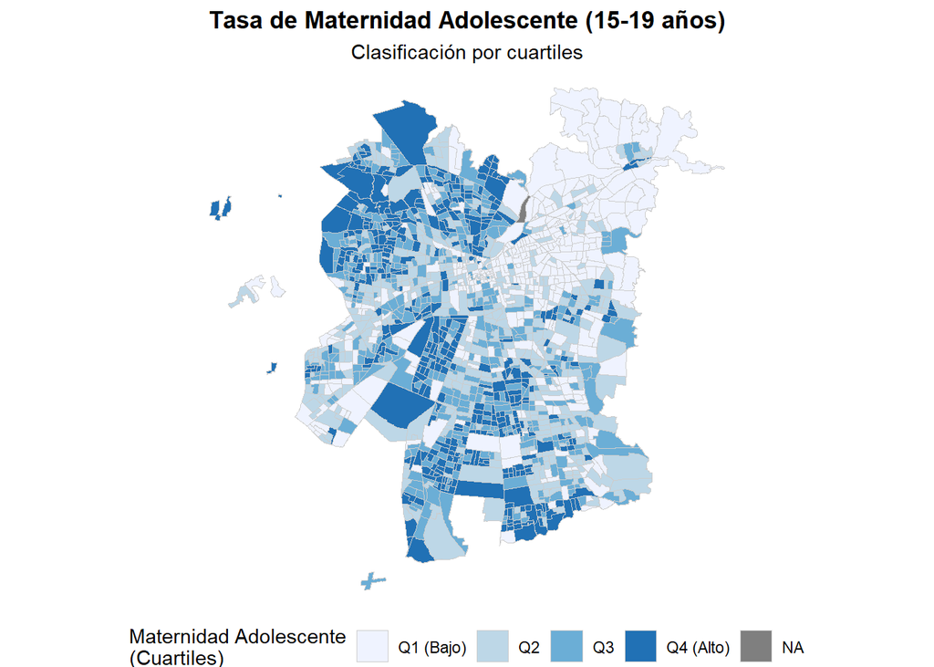

El despliegue cartográfico muestra la distribución de la tasa de maternidad adolescente (15-19 años) en el Gran Santiago, clasificada por cuartiles. Esta representación permite identificar con claridad las diferencias territoriales en la incidencia del fenómeno.

Los colores representan los rangos de los Cuartiles:

- Q1: Representado en color blanco, agrupa las zonas con las tasas más bajas de maternidad adolescente.
- Q2 y Q3: En tonos crecientes de azul claro, muestran valores intermedios del indicador.
- Q4: En azul oscuro, destaca las zonas con las tasas más altas de maternidad.
- NA: corresponden a las zonas con datos no disponibles.

Se observa una concentración de zonas con altas tasas de maternidad adolescente (Q4) en sectores periféricos y del sur de la ciudad, especialmente en algunas zonas censales del sector poniente-norte, así como en comunas como Puente Alto y San Bernardo. En contraste, las zonas con menor incidencia (Q1) se ubican principalmente en el sector oriente y en algunas áreas del centro, donde las tasas son considerablemente más bajas. Esta distribución evidencia desigualdades territoriales que podrían estar relacionadas con factores estructurales como el acceso a la educación, servicios de salud sexual y reproductiva, y condiciones socioeconómicas más amplias.

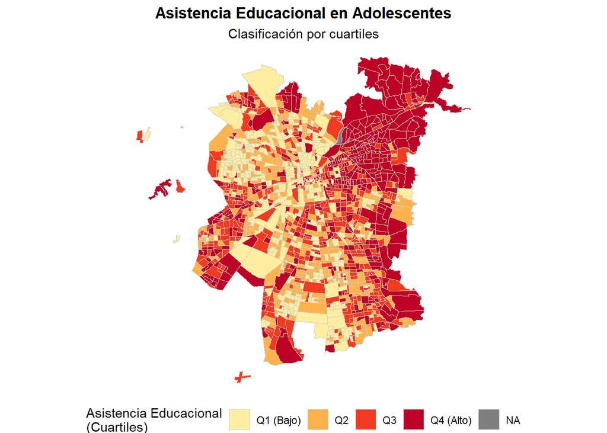

El mapa representa las tasas de participación en educación formal del grupo poblacional de mujeres adolescentes, distribuidas a largo del territorio del Gran Santiago. Cada cuartil representa un nivel distinto de asistencia educacional en donde:

- Q1 (Bajo): Áreas en color amarillo claro, representan las zonas con los niveles más bajos de asistencia educacional.
- Q2 y Q3: en tonos naranja y rojo, indican niveles intermedios.
- Q4: Utiliza el color rojo oscuro, destacando las zonas con alta asistencia educacional adolescente (concentraciones de datos que superan al percentil 75%)
- NA: Zonas con datos faltantes o no disponibles.

### 2.3.2- Mapa Bivariado

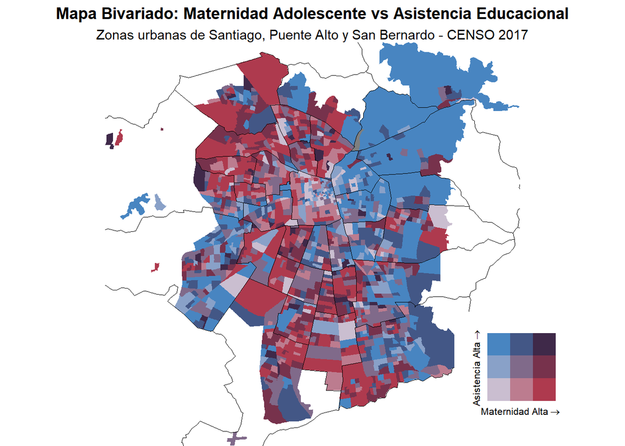

El mapa bivariado muestra la relación espacial entre la maternidad adolescente y la asistencia educacional en las zonas urbanas del Gran Santiago según el Censo 2017. Ambas variables fueron clasificadas en terciles, de modo que los colores representan la combinación de sus niveles relativos:

- Rojo intenso: alta maternidad adolescente y baja asistencia educacional.
- Azul intenso: baja maternidad adolescente y alta asistencia educacional.
- Tonos intermedios (violetas o lilas): valores medios o combinaciones equilibradas entre ambas variables.

Teniendo en cuenta este gradiente de color es posible identificar la concentración de tonos rojos en el sur y poniente de Santiago, especialmente en comunas como La Pintana, San Ramón, El Bosque y partes de Puente Alto, lo que refleja altas tasas de maternidad adolescente y baja asistencia educacional.

Por el contrario, las zonas nororiente y oriente (como Las Condes, Vitacura, Ñuñoa y Providencia) se caracterizan por tonos azules, indicando baja maternidad adolescente y alta asistencia educacional.

# 3 - Conclusión

El presente estudio permitió identificar patrones espaciales significativos en la distribución de la maternidad adolescente y su relación con la asistencia educacional en el Gran Santiago. Los resultados confirman la existencia de una clara correlación negativa entre ambas variables, evidenciando que las zonas con mayores tasas de maternidad adolescente tienden a presentar menores niveles de asistencia educacional, y viceversa.

El análisis espacial reveló una marcada segregación territorial, donde las comunas del sector oriente (Las Condes, Vitacura, Ñuñoa) muestran consistentemente bajas tasas de maternidad adolescente y altos niveles de asistencia educacional. Por el contrario, las comunas del sur y poniente de la ciudad (La Pintana, San Ramón, El Bosque, sectores de Puente Alto y San Bernardo) concentran las situaciones de mayor vulnerabilidad, con altas tasas de maternidad adolescente y baja asistencia educacional.

Estos hallazgos adquieren especial relevancia al considerar que, si bien a nivel nacional se han registrado avances en la reducción del embarazo adolescente, como señala Orellana (2025, citado en CNN Chile): “Es una buena noticia porque los embarazos adolescentes suelen estar asociados a trayectorias de pobreza, de cesión escolar y también pobreza país. Es un indicador de desarrollo, porque se combina educación, permanencia en la educación, acceso a anticonceptivos e información”. Sin embargo, esta investigación demuestra que estas mejoras no se han distribuido de manera homogénea en el territorio, existiendo localidades con una alta ocurrencia de embarazo adolescente que reflejan la profundidad de la segregación espacial en la región metropolitana.

Los resultados respaldan además la afirmación de Huerta Wong (2012) sobre el rol fundamental de la educación como herramienta para superar barreras estructurales. La evidencia sugiere que intervenciones focalizadas en promover la permanencia escolar en territorios críticos podrían contribuir significativamente a reducir la incidencia de la maternidad adolescente, especialmente en contextos de desventaja socioeconómica.

Desde la perspectiva de políticas públicas, los mapas bivariados generados constituyen una herramienta valiosa para la focalización territorial de intervenciones, permitiendo identificar Zonas Censales específicas que requieren atención prioritaria. La metodología empleada demuestra el valor del análisis geoespacial para comprender fenómenos sociales complejos y diseñar estrategias de intervención más efectivas y contextualizadas.

Finalmente, este estudio subraya la necesidad de abordar la problemática de la maternidad adolescente desde un enfoque integral que combine componentes educativos, de salud sexual y reproductiva, y de desarrollo socioeconómico, considerando siempre las particularidades territoriales que caracterizan la distribución de estas vulnerabilidades en el espacio urbano.

# 4 - Bibliografía

- Huerta Wong, J. E. (2012). *El rol de la educación en la movilidad social de México y Chile: ¿La desigualdad por otras vías?* Revista Mexicana de Investigación Educativa, 17(52), 65–88. https://www.scielo.org.mx/pdf/rmie/v17n52/v17n52a4.pdf
- Instituto Nacional de Estadísticas (INE). (2017). *Censo de Población y Vivienda 2017*. Recuperado de https://www.censo2017.cl
- CNN Chile. (2025, mayo 3). *Ministra Orellana y caída de la natalidad en Chile: “El descenso radical del embarazo adolescente es algo que nos debe alegrar”*. https://www.cnnchile.com/pais/ministra-orellana-caida-natalidad-chile-descenso-radical-embarazo-adolescente-algo-debe-alegrar_20250503/